# R语言与机器学习（下）

## 11.5 特征重要性解释

### 排列重要性

**原理**：随机打乱某个特征的值，观察模型性能下降程度。

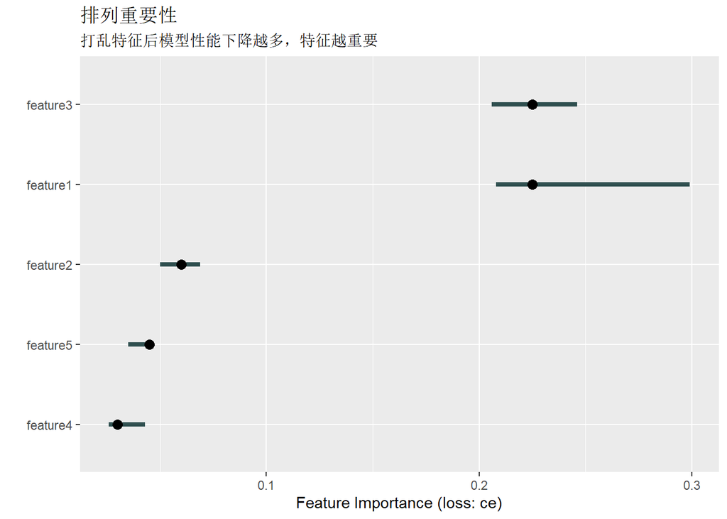

```r
# 排列重要性示例
# 使用iml包

set.seed(42)

# 训练模型
model <- randomForest::randomForest(target ~ ., data = rf_data)

# 创建预测器对象
predictor <- iml::Predictor$new(model, data = rf_data[, -6], y = rf_data$target)

# 计算排列重要性
perm_importance <- iml::FeatureImp$new(predictor, loss = "ce")

# 可视化
plot(perm_importance) +
  ggplot2::labs(
    title = "排列重要性",
    subtitle = "打乱特征后模型性能下降越多，特征越重要"
  )
```

### SHAP值

**原理**：基于博弈论，计算每个特征对预测的贡献。

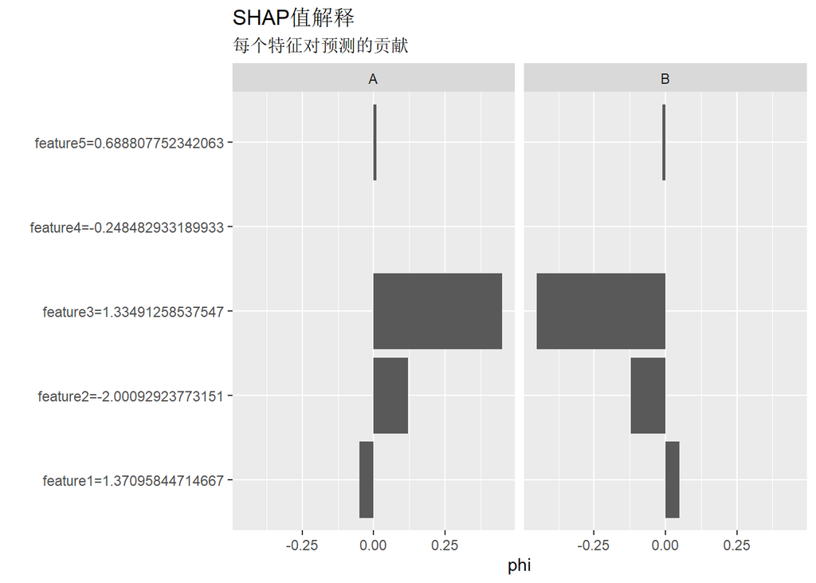

```r
# SHAP值示例
# 使用iml包

# 创建SHAP解释器
shap_explainer <- iml::Shapley$new(predictor, x.interest = rf_data[1, -6])

# 可视化单个样本的SHAP值
plot(shap_explainer) +
  ggplot2::labs(
    title = "SHAP值解释",
    subtitle = "每个特征对预测的贡献"
  )
```

### 意义与使用场景

**核心意义**：特征重要性解释帮助理解模型决策依据，提高模型可解释性。

**举例**：疾病风险预测模型解释

**为什么需要特征重要性解释？**

医生需要理解模型为什么预测某患者为高风险，才能信任并采纳模型建议。特征重要性可以告诉医生哪些因素导致了高风险预测。

**研究目的是什么？**

1. 模型解释：理解模型的决策逻辑
2. 特征验证：确认重要特征符合医学知识
3. 发现新线索：可能发现新的风险因素

**可能得到什么样的结果？**

模型可能显示”年龄”和”血压”是最重要的预测因素，这与医学知识一致，增加了模型的可信度。

**需要注意什么？**

特征重要性不等于因果关系。相关性强的特征可能被模型高度依赖，但不一定是真正的病因。

## 11.6 PCA作为特征提取

### 特征选择 vs 特征提取

| 对比维度 | 特征选择 | 特征提取 |
| --- | --- | --- |
| 方法 | 选择原始特征子集 | 创建新特征 |
| 可解释性 | 保持原始特征含义 | 新特征难以解释 |
| 信息保留 | 可能丢失信息 | 压缩信息 |
| 典型方法 | 过滤法、包装法 | PCA、LDA |

```r
# PCA特征提取示例
set.seed(42)

# 创建高维数据
n <- 100
p <- 20

pca_feat_data <- matrix(rnorm(n * p), nrow = n, ncol = p)
colnames(pca_feat_data) <- paste0("Feature_", 1:p)

# 添加分组结构
pca_feat_data[1:50, 1:5] <- pca_feat_data[1:50, 1:5] + 2

# 执行PCA
pca_feat <- prcomp(pca_feat_data, scale. = TRUE)

# 使用前5个主成分作为新特征
pca_features <- pca_feat$x[, 1:5]

# 查看新特征的方差贡献
var_explained <- pca_feat$sdev^2 / sum(pca_feat$sdev^2)
print("前5个主成分的方差贡献：")
```

```
## [1] "前5个主成分的方差贡献："
```

```r
print(round(cumsum(var_explained)[5], 3))
```

```
## [1] 0.466
```

## 11.7 LDA作为特征提取

### LDA特征提取原理

**线性判别分析（LDA）** 寻找最能区分类别的投影方向，可用于特征提取。

```r
# LDA特征提取示例
set.seed(42)

# 创建带标签的数据
n <- 100
lda_feat_data <- data.frame(
  x1 = c(rnorm(n/2, 0, 1), rnorm(n/2, 3, 1)),
  x2 = c(rnorm(n/2, 0, 1), rnorm(n/2, 3, 1)),
  x3 = rnorm(n),  # 噪声特征
  x4 = rnorm(n),  # 噪声特征
  class = factor(rep(c("A", "B"), each = n/2))
)

# 执行LDA
lda_feat <- MASS::lda(class ~ x1 + x2 + x3 + x4, data = lda_feat_data)

# 查看判别函数
print("LDA判别函数系数：")
```

```
## [1] "LDA判别函数系数："
```

```r
print(lda_feat$scaling)
```

```
##            LD1
## x1 0.621599492
## x2 0.820935594
## x3 0.030917345
## x4 0.005188053
```

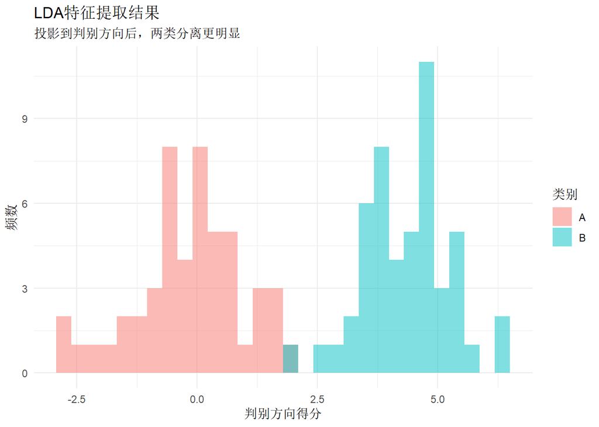

```r
# 投影到判别方向
lda_projection <- as.matrix(lda_feat_data[, 1:4]) %*% lda_feat$scaling

# 可视化
lda_feat_data$LD1 <- lda_projection[, 1]

ggplot2::ggplot(lda_feat_data, ggplot2::aes(x = LD1, fill = class)) +
  ggplot2::geom_histogram(position = "identity", alpha = 0.5, bins = 30) +
  ggplot2::labs(
    title = "LDA特征提取结果",
    subtitle = "投影到判别方向后，两类分离更明显",
    x = "判别方向得分", y = "频数", fill = "类别"
  ) +
  ggplot2::theme_minimal()
```

### 意义与使用场景

**核心意义**：特征提取创建新的综合特征，可以在降低维度的同时保留关键信息。

**举例**：医学影像特征压缩

**为什么这种数据适合用特征提取？**

医学影像可能提取出数百个纹理、形状特征，其中很多高度相关。PCA可以将这些特征压缩为少数几个综合特征，同时保留大部分信息。

**研究目的是什么？**

1. 降维：减少特征数量，降低计算复杂度
2. 去相关：消除特征间的冗余
3. 降噪：去除方差较小的成分

**可能得到什么样的结果？**

从100个影像特征中提取10个主成分，可能保留了90%的信息量，同时大大简化了模型。

**需要注意什么？**

提取的特征是原始特征的线性组合，可解释性较差。需要权衡降维效果和可解释性。

# 第十二章 模型解释与可解释性

## 12.1 可解释性基本概念

### 为什么需要可解释性？

**模型可解释性（Model Interpretability）** 指人类能够理解模型决策原因的程度。在医学领域尤为重要：

| 原因 | 说明 |
| --- | --- |
| 信任建立 | 医生需要理解模型才能信任 |
| 伦理要求 | 医疗决策需要可解释 |
| 监管合规 | 医疗AI需要通过审核 |
| 错误诊断 | 发现模型的潜在问题 |

### 全局解释 vs 局部解释

| 类型 | 定义 | 目的 |
| --- | --- | --- |
| 全局解释 | 解释模型整体行为 | 理解模型如何工作 |
| 局部解释 | 解释单个预测 | 理解特定预测的原因 |

### 可解释性方法分类

| 方法 | 适用模型 | 特点 |
| --- | --- | --- |
| 特征重要性 | 所有模型 | 全局解释 |
| PDP/ICE | 所有模型 | 全局/局部解释 |
| SHAP | 所有模型 | 局部解释 |
| LIME | 所有模型 | 局部解释 |
| 替代模型 | 复杂模型 | 全局解释 |

### 意义与使用场景

**核心意义**：可解释性是医疗AI落地的关键，帮助建立信任和发现错误。

**举例**：疾病诊断模型解释

**为什么需要可解释性？**

医生不会仅凭一个”黑箱”模型的预测就做出诊断决策。他们需要知道模型为什么做出这个预测，哪些因素是关键，这有助于医生判断模型预测是否合理。

**研究目的是什么？**

1. 建立信任：让医生理解并信任模型
2. 发现错误：识别模型的潜在偏见
3. 辅助决策：提供决策依据

**可能得到什么样的结果？**

模型可能显示”肿瘤大小”和”边界清晰度”是诊断恶性的主要因素，这与医学知识一致。

**需要注意什么？**

可解释性方法本身也可能有偏见，需要多种方法交叉验证。

## 12.2 特征重要性（Feature Importance）

### 基本原理

**特征重要性** 衡量每个特征对模型预测的贡献程度。

**常用方法**： 1. 基于模型的内置重要性（如随机森林的Gini重要性） 2. 排列重要性（Permutation Importance）

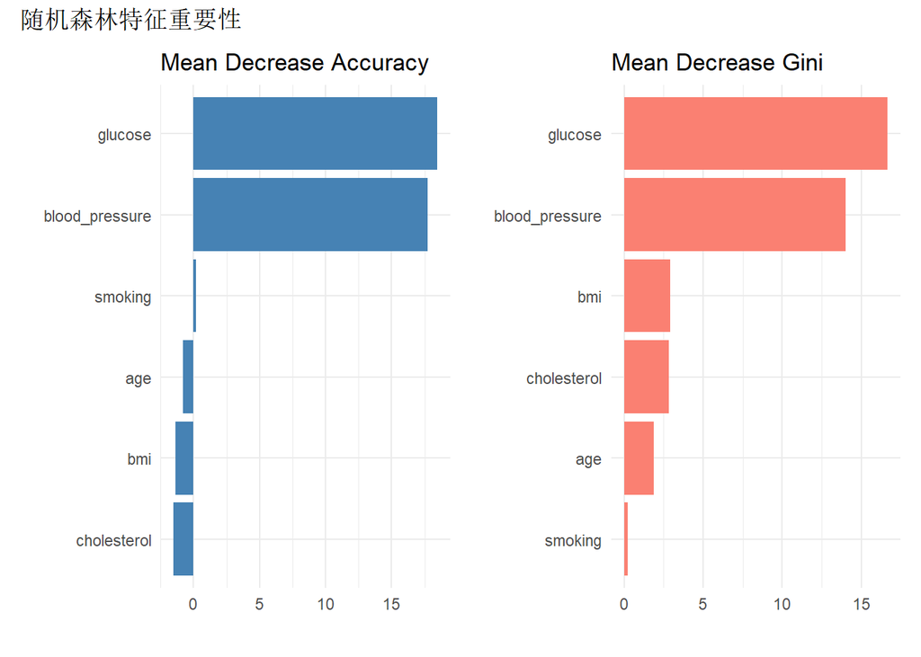

```r
# 特征重要性示例
set.seed(42)

# 创建模拟疾病预测数据
n <- 300
disease_data <- data.frame(
  age = round(rnorm(n, 50, 15)),
  blood_pressure = rnorm(n, 120, 20),
  cholesterol = rnorm(n, 200, 40),
  bmi = rnorm(n, 25, 5),
  glucose = rnorm(n, 100, 20),
  smoking = factor(sample(c("Yes", "No"), n, replace = TRUE)),
  disease = factor(sample(c("Disease", "Healthy"), n, replace = TRUE))
)

# 让某些特征与疾病相关
disease_data$disease <- factor(ifelse(
  disease_data$blood_pressure > 130 & disease_data$glucose > 110,
  "Disease", "Healthy"
))

# 训练随机森林模型
rf_model <- randomForest::randomForest(disease ~ ., data = disease_data,
                                        importance = TRUE, ntree = 100)

# 获取特征重要性
importance_matrix <- randomForest::importance(rf_model)

# 创建数据框用于可视化
imp_df <- data.frame(
  Feature = rownames(importance_matrix),
  MeanDecreaseAccuracy = importance_matrix[, "MeanDecreaseAccuracy"],
  MeanDecreaseGini = importance_matrix[, "MeanDecreaseGini"]
)

# 可视化
p1 <- ggplot2::ggplot(imp_df, ggplot2::aes(x = reorder(Feature, MeanDecreaseAccuracy), y = MeanDecreaseAccuracy)) +
  ggplot2::geom_bar(stat = "identity", fill = "steelblue") +
  ggplot2::coord_flip() +
  ggplot2::labs(title = "Mean Decrease Accuracy", x = "", y = "") +
  ggplot2::theme_minimal()

p2 <- ggplot2::ggplot(imp_df, ggplot2::aes(x = reorder(Feature, MeanDecreaseGini), y = MeanDecreaseGini)) +
  ggplot2::geom_bar(stat = "identity", fill = "salmon") +
  ggplot2::coord_flip() +
  ggplot2::labs(title = "Mean Decrease Gini", x = "", y = "") +
  ggplot2::theme_minimal()

p1 + p2 + patchwork::plot_annotation(
  title = "随机森林特征重要性"
)
```

### 排列重要性

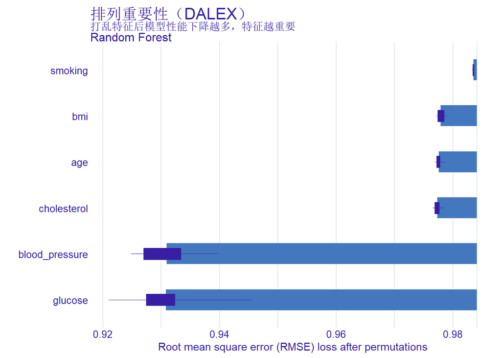

```r
# 使用DALEX包计算排列重要性
library(DALEX)

# 创建解释器
explainer_rf <- DALEX::explain(
  model = rf_model,
  data = disease_data[, -7],
  y = as.numeric(disease_data$disease == "Disease"),
  label = "Random Forest",
  verbose = FALSE
)

# 计算排列重要性
set.seed(42)
vip_rf <- DALEX::model_parts(explainer_rf,
                              loss_function = DALEX::loss_root_mean_square)

# 可视化
plot(vip_rf) +
  ggplot2::labs(
    title = "排列重要性（DALEX）",
    subtitle = "打乱特征后模型性能下降越多，特征越重要"
  )
```

## 12.3 部分依赖图（PDP）与个体条件期望（ICE）

### 部分依赖图原理

**部分依赖图（Partial Dependence Plot, PDP）** 展示特征对预测的平均影响：

$$\text{PD}(x_s) = \frac{1}{n}
\sum_{i=1}^{n} f(x_s, x_{c}^{(i)})$$

其中$x_s$是感兴趣的特征，$x_c$是其他特征。

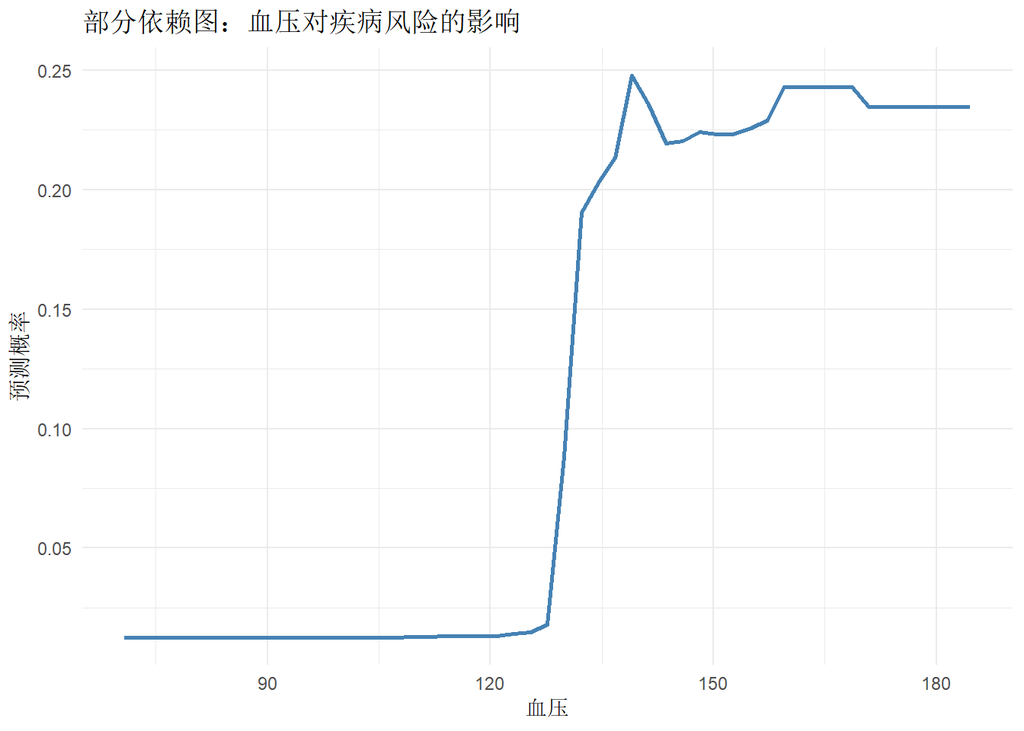

```r
# PDP示例
library(pdp)

# 计算血压的部分依赖
pdp_bp <- pdp::partial(rf_model,
                        pred.var = "blood_pressure",
                        train = disease_data[, -7],
                        prob = TRUE)

# 可视化
ggplot2::ggplot(pdp_bp, ggplot2::aes(x = blood_pressure, y = yhat)) +
  ggplot2::geom_line(color = "steelblue", linewidth = 1) +
  ggplot2::labs(
    title = "部分依赖图：血压对疾病风险的影响",
    x = "血压", y = "预测概率"
  ) +
  ggplot2::theme_minimal()
```

### 个体条件期望（ICE）

**ICE图** 展示每个样本的预测曲线，比PDP提供更详细的信息。

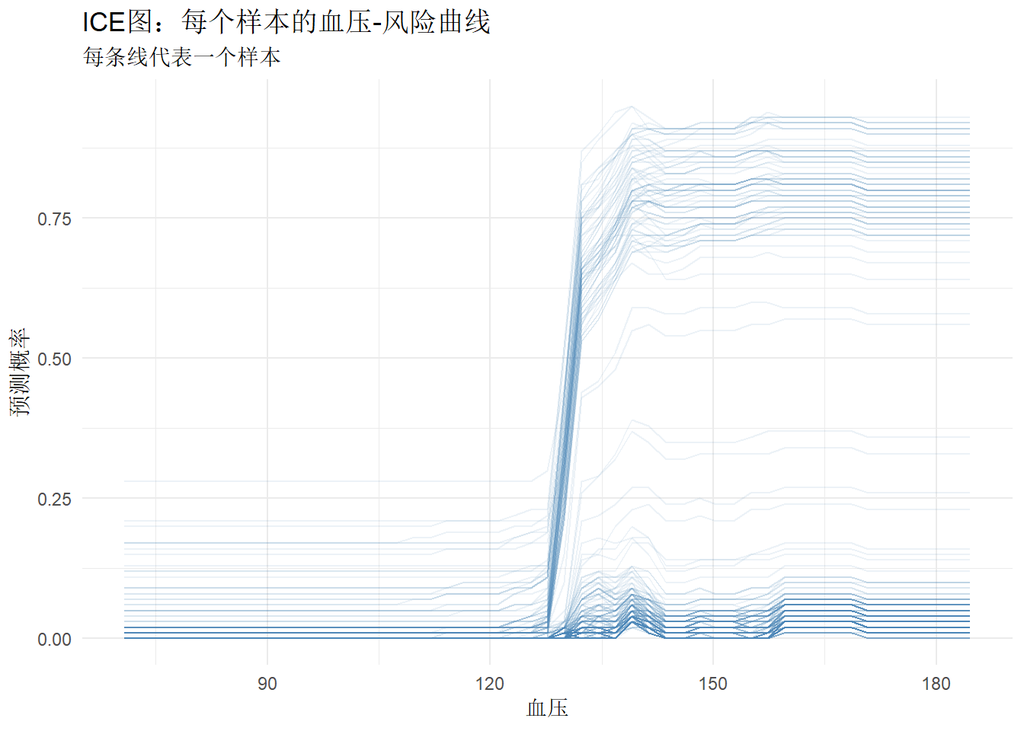

```r
# ICE图示例
ice_bp <- pdp::partial(rf_model,
                        pred.var = "blood_pressure",
                        train = disease_data[, -7],
                        ice = TRUE,
                        prob = TRUE)

# 可视化ICE曲线
ggplot2::ggplot(ice_bp, ggplot2::aes(x = blood_pressure, y = yhat, group = yhat.id)) +
  ggplot2::geom_line(alpha = 0.1, color = "steelblue") +
  ggplot2::labs(
    title = "ICE图：每个样本的血压-风险曲线",
    subtitle = "每条线代表一个样本",
    x = "血压", y = "预测概率"
  ) +
  ggplot2::theme_minimal()
```

### 意义与使用场景

**核心意义**：PDP和ICE展示特征与预测的关系，帮助理解模型行为。

**举例**：药物剂量-效应关系分析

**为什么这种数据适合用PDP/ICE？**

药物剂量与疗效的关系可能非线性，PDP可以展示这种关系，帮助确定最佳剂量范围。

**研究目的是什么？**

1. 理解特征影响：展示特征如何影响预测
2. 发现非线性：识别非线性关系
3. 确定阈值：找到关键决策点

**可能得到什么样的结果？**

PDP可能显示血压超过130后，疾病风险急剧上升，提示这是关键阈值。

**需要注意什么？**

PDP假设特征独立，如果特征相关，结果可能有误导。

## 12.4 SHAP值

### SHAP原理

**SHAP（SHapley Additive exPlanations）** 基于博弈论，计算每个特征对预测的边际贡献：

**核心思想**：考虑所有可能的特征组合，计算特征加入时的平均贡献。

$$\phi_i = \sum_{S \subseteq F \setminus
\{i\}} \frac{|S|!(|F|-|S|-1)!}{|F|!} [f(S \cup \{i\}) -
f(S)]$$

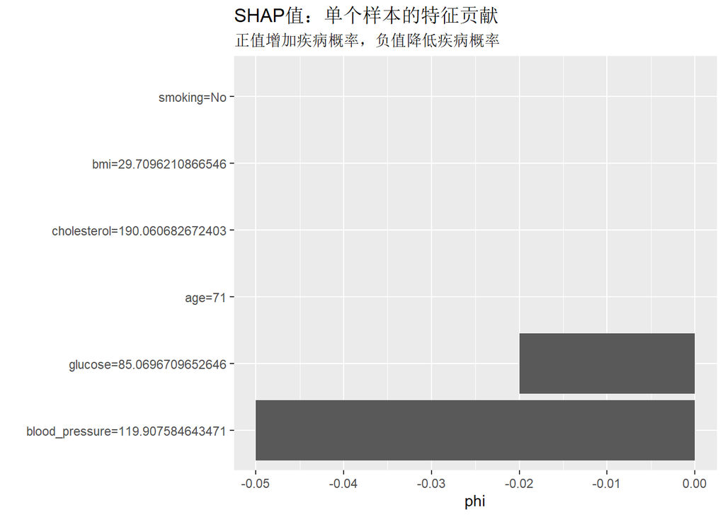

```r
# SHAP值示例
# 使用iml包

set.seed(42)

# 创建预测器
predictor <- iml::Predictor$new(
  rf_model,
  data = disease_data[, -7],
  y = disease_data$disease,
  class = "Disease"
)

# 计算单个样本的SHAP值
shap_single <- iml::Shapley$new(predictor, x.interest = disease_data[1, -7])

# 可视化
plot(shap_single) +
  ggplot2::labs(
    title = "SHAP值：单个样本的特征贡献",
    subtitle = "正值增加疾病概率，负值降低疾病概率"
  )
```

### 多样本SHAP分析

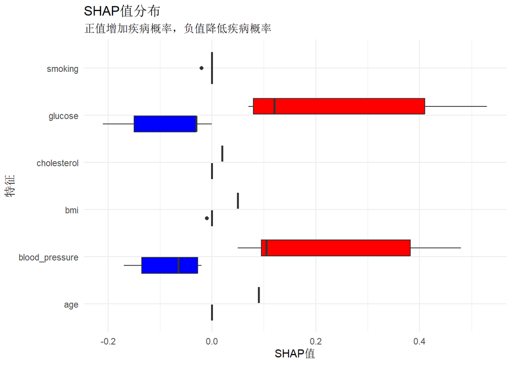

```r
# 计算多个样本的SHAP值
shap_values <- data.frame()

for (i in sample(1:nrow(disease_data), 20)) {
  shap_i <- iml::Shapley$new(predictor, x.interest = disease_data[i, -7])
  shap_df <- shap_i$results
  shap_df$sample_id <- i
  shap_values <- rbind(shap_values, shap_df)
}

# 可视化SHAP值分布
ggplot2::ggplot(shap_values, ggplot2::aes(x = feature, y = phi, fill = phi > 0)) +
  ggplot2::geom_boxplot() +
  ggplot2::scale_fill_manual(values = c("TRUE" = "red", "FALSE" = "blue")) +
  ggplot2::coord_flip() +
  ggplot2::labs(
    title = "SHAP值分布",
    subtitle = "正值增加疾病概率，负值降低疾病概率",
    x = "特征", y = "SHAP值"
  ) +
  ggplot2::theme_minimal() +
  ggplot2::theme(legend.position = "none")
```

### 意义与使用场景

**核心意义**：SHAP提供最全面的特征贡献解释，是当前最流行的可解释性方法。

**举例**：个体化治疗方案解释

**为什么这种数据适合用SHAP？**

每个患者的疾病风险因素组合不同，SHAP可以为每个患者提供个性化的风险因素解释。

**研究目的是什么？**

1. 个性化解释：为每个患者提供定制化解释
2. 特征贡献量化：精确计算每个因素的贡献
3. 干预建议：识别可干预的风险因素

**可能得到什么样的结果？**

对于某患者，SHAP可能显示”高血压贡献+15%，高血糖贡献+10%，年龄贡献+5%“。

**需要注意什么？**

SHAP计算量大，对大规模数据可能较慢。结果依赖于模型质量。

## 12.5 LIME

### LIME原理

**LIME（Local Interpretable Model-agnostic Explanations）** 通过在局部拟合简单模型来解释复杂模型：

**核心思想**：在待解释样本附近生成扰动数据，用简单模型拟合局部行为。

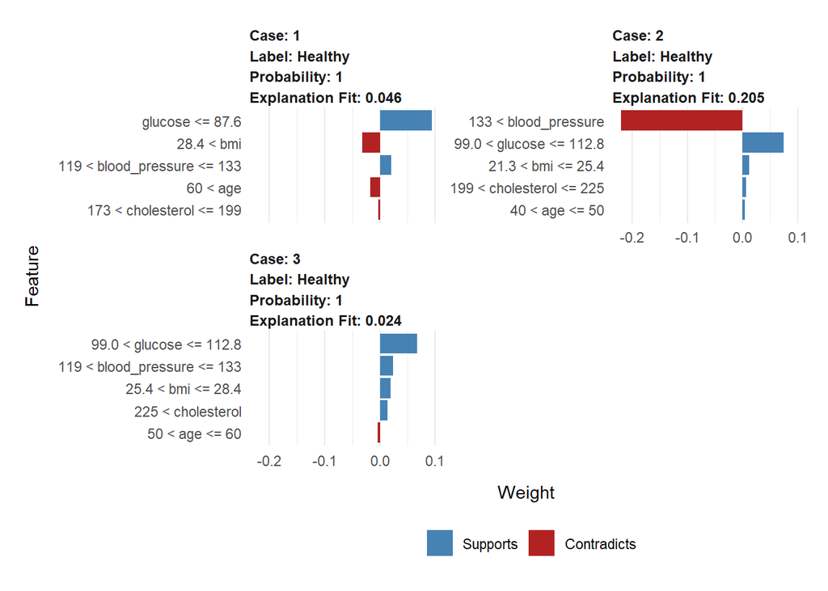

```r
# LIME示例
library(lime)
library(caret)

# 为LIME准备数据（仅使用数值特征）
lime_data <- disease_data[, c("age", "blood_pressure", "cholesterol", "bmi", "glucose")]
lime_labels <- disease_data$disease

# 使用caret训练模型（lime对caret模型有更好的支持）
caret_model <- caret::train(
  x = lime_data,
  y = lime_labels,
  method = "rf",
  ntree = 100,
  trControl = caret::trainControl(method = "none"),
  tuneGrid = data.frame(mtry = 2)
)

# 创建LIME解释器
lime_explainer <- lime::lime(
  x = lime_data,
  model = caret_model
)

# 解释单个样本
lime_explanation <- lime::explain(
  x = lime_data[1:3, ],
  explainer = lime_explainer,
  n_features = 5,
  n_labels = 1
)

# 可视化
plot_features(lime_explanation)
```

### LIME vs SHAP对比

| 对比维度 | LIME | SHAP |
| --- | --- | --- |
| 理论基础 | 局部线性近似 | 博弈论 |
| 计算速度 | 较快 | 较慢 |
| 一致性 | 可能不稳定 | 保证一致性 |
| 可解释性 | 局部解释 | 全局+局部解释 |

## 12.6 替代模型

### 基本原理

**替代模型（Surrogate Model）** 用简单可解释的模型近似复杂模型：

**步骤**： 1. 用复杂模型预测所有样本 2. 用简单模型（如决策树）拟合预测结果 3. 解释简单模型

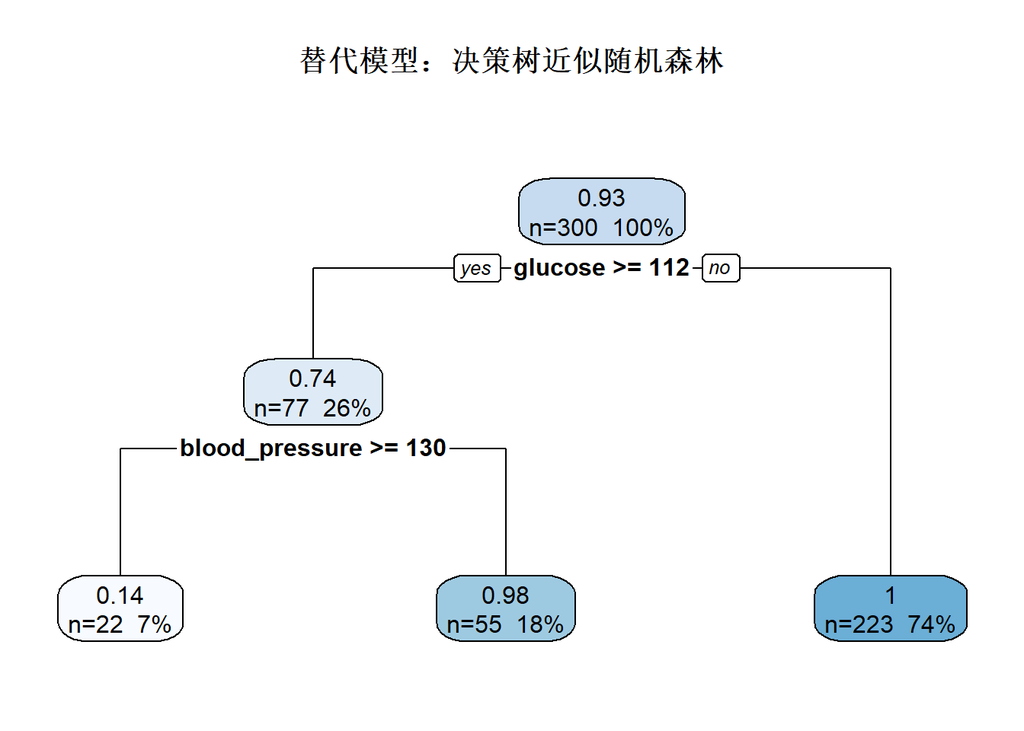

```r
# 替代模型示例
set.seed(42)

# 获取复杂模型的预测
complex_predictions <- predict(rf_model, disease_data[, -7], type = "prob")[, 2]

# 用决策树拟合预测结果
surrogate_tree <- rpart::rpart(
  complex_predictions ~ age + blood_pressure + cholesterol + bmi + glucose + smoking,
  data = disease_data,
  method = "anova",
  control = rpart::rpart.control(maxdepth = 3)
)

# 可视化决策树
rpart.plot::rpart.plot(surrogate_tree,
                        main = "替代模型：决策树近似随机森林",
                        type = 2,
                        extra = 101)
```

## 12.7 模型公平性评估

### 公平性概念

**模型公平性（Model Fairness）** 确保模型对不同群体没有歧视：

| 公平性指标 | 定义 |
| --- | --- |
| 人口统计学均等 | 不同群体的预测率相同 |
| 机会均等 | 不同群体的真阳性率相同 |
| 预测均等 | 不同群体的精确率相同 |

```r
# 公平性评估示例
# 假设我们关注模型对不同年龄组的公平性

# 创建年龄组
disease_data$age_group <- cut(disease_data$age,
                               breaks = c(0, 40, 60, 100),
                               labels = c("Young", "Middle", "Senior"))

# 获取预测
disease_data$predicted <- predict(rf_model, disease_data[, -7])

# 计算各年龄组的性能
fairness_metrics <- disease_data %>%
  dplyr::group_by(age_group) %>%
  dplyr::summarise(
    accuracy = mean(predicted == disease),
    disease_rate = mean(disease == "Disease"),
    predicted_rate = mean(predicted == "Disease")
  )

print("各年龄组的模型表现：")
```

```
## [1] "各年龄组的模型表现："
```

```r
print(fairness_metrics)
```

```
## # A tibble: 3 × 4
##   age_group accuracy disease_rate predicted_rate
##   <fct>        <dbl>        <dbl>          <dbl>
## 1 Young            1       0.103          0.103
## 2 Middle           1       0.0452         0.0452
## 3 Senior           1       0.104          0.104
```

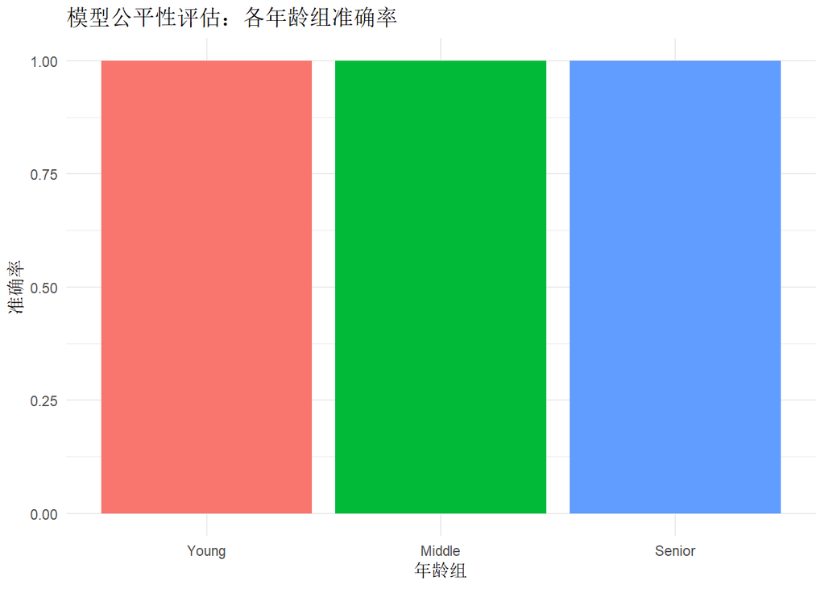

```r
# 可视化
ggplot2::ggplot(fairness_metrics, ggplot2::aes(x = age_group, y = accuracy, fill = age_group)) +
  ggplot2::geom_bar(stat = "identity") +
  ggplot2::labs(
    title = "模型公平性评估：各年龄组准确率",
    x = "年龄组", y = "准确率"
  ) +
  ggplot2::theme_minimal() +
  ggplot2::theme(legend.position = "none")
```

### 意义与使用场景

**核心意义**：公平性评估确保模型对所有患者群体公平，避免医疗歧视。

**举例**：不同种族的疾病预测公平性

**为什么需要公平性评估？**

如果模型主要用某一种族的数据训练，可能对其他种族预测不准，导致医疗不公平。

**研究目的是什么？**

1. 发现偏见：识别模型对某些群体的歧视
2. 改进模型：调整模型提高公平性
3. 合规审查：满足监管要求

**可能得到什么样的结果？**

可能发现模型对老年患者的准确率较低，需要收集更多老年患者数据重新训练。

**需要注意什么？**

公平性和准确性可能存在权衡，需要根据具体场景平衡。

# 第十三章 时间序列机器学习

## 13.1 时间序列监督学习范式

### 时间序列特点

**时间序列数据** 具有时间依赖性，样本间存在顺序关系：

| 特点 | 说明 |
| --- | --- |
| 时间依赖 | 当前值与历史值相关 |
| 趋势 | 长期上升或下降趋势 |
| 季节性 | 周期性重复模式 |
| 周期性 | 非固定周期的波动 |
| 不规则性 | 随机波动 |

### 滑动窗口构建特征

**核心思想**：将时间序列转换为监督学习问题，用历史值预测未来值。

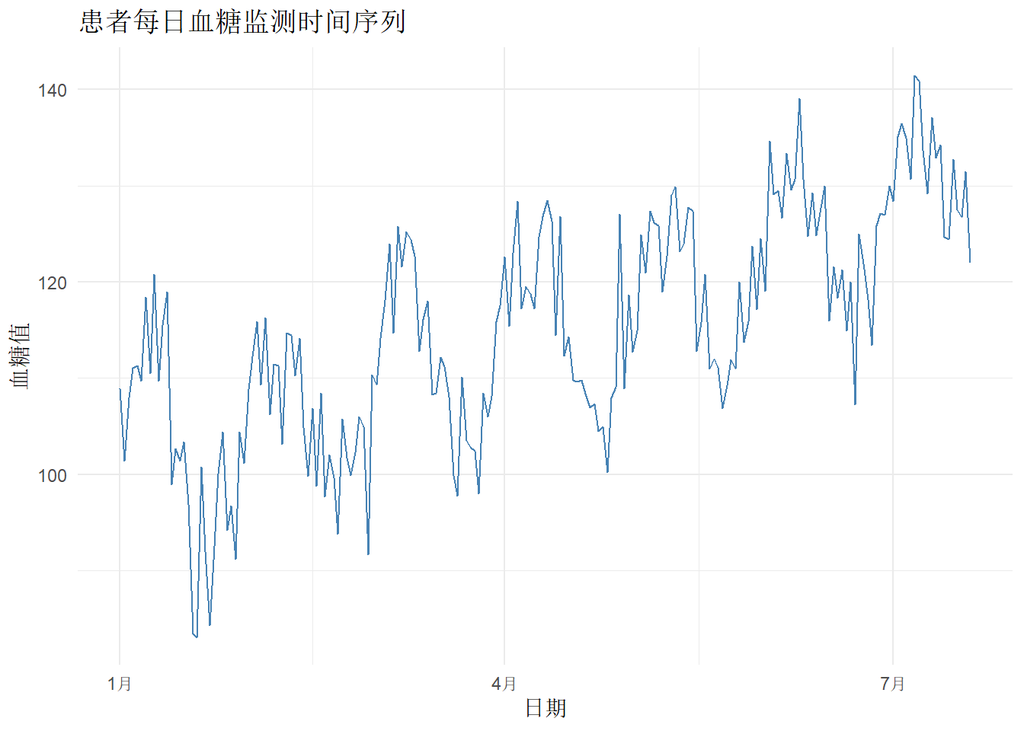

```r
# 时间序列监督学习示例
set.seed(42)

# 创建模拟的时间序列数据：患者每日血糖监测
n_days <- 200
dates <- seq(as.Date("2023-01-01"), by = "day", length.out = n_days)

# 生成带有趋势和季节性的血糖数据
trend <- seq(100, 130, length.out = n_days)
seasonal <- 10 * sin(2 * pi * (1:n_days) / 30)  # 月周期
noise <- rnorm(n_days, 0, 5)
glucose <- trend + seasonal + noise

ts_data <- data.frame(
  date = dates,
  glucose = glucose
)

# 可视化原始时间序列
ggplot2::ggplot(ts_data, ggplot2::aes(x = date, y = glucose)) +
  ggplot2::geom_line(color = "steelblue") +
  ggplot2::labs(
    title = "患者每日血糖监测时间序列",
    x = "日期", y = "血糖值"
  ) +
  ggplot2::theme_minimal()
```

```r
# 构建滑动窗口特征
create_lagged_features <- function(data, lag = 7) {
  n <- nrow(data)
  result <- data.frame(date = data$date[(lag+1):n])

  for (i in 1:lag) {
    result[[paste0("lag_", i)]] <- data$glucose[(lag+1-i):(n-i)]
  }

  result$target <- data$glucose[(lag+1):n]
  return(result)
}

# 创建滞后特征
lagged_data <- create_lagged_features(ts_data, lag = 7)

# 查看数据结构
head(lagged_data)
```

```
##         date    lag_1    lag_2    lag_3    lag_4    lag_5    lag_6    lag_7
## 1 2023-01-08 118.4074 109.7337 111.2846 111.0480 107.9950 101.3946 108.9339
## 2 2023-01-09 110.5272 118.4074 109.7337 111.2846 111.0480 107.9950 101.3946
## 3 2023-01-10 120.8087 110.5272 118.4074 109.7337 111.2846 111.0480 107.9950
## 4 2023-01-11 109.7035 120.8087 110.5272 118.4074 109.7337 111.2846 111.0480
## 5 2023-01-12 115.4633 109.7035 120.8087 110.5272 118.4074 109.7337 111.2846
## 6 2023-01-13 118.9694 115.4633 109.7035 120.8087 110.5272 118.4074 109.7337
##      target
## 1 110.52720
## 2 120.80871
## 3 109.70347
## 4 115.46333
## 5 118.96937
## 6  98.93211
```

### 意义与使用场景

**核心意义**：滑动窗口将时间序列转换为监督学习问题，可以使用传统机器学习方法。

**举例**：血糖预测

**为什么这种数据适合用滑动窗口？**

血糖值具有时间依赖性，今天的血糖与过去几天的血糖相关。滑动窗口可以捕捉这种依赖关系。

**研究目的是什么？**

1. 短期预测：预测明天的血糖值
2. 异常预警：预测血糖异常波动
3. 干预评估：评估治疗效果

**可能得到什么样的结果？**

模型可能准确预测未来1-3天的血糖值，帮助患者提前调整饮食和用药。

**需要注意什么？**

滑动窗口大小需要根据数据特点选择。窗口太小可能丢失信息，太大可能引入噪声。

## 13.2 时间序列特征工程

### 滞后特征

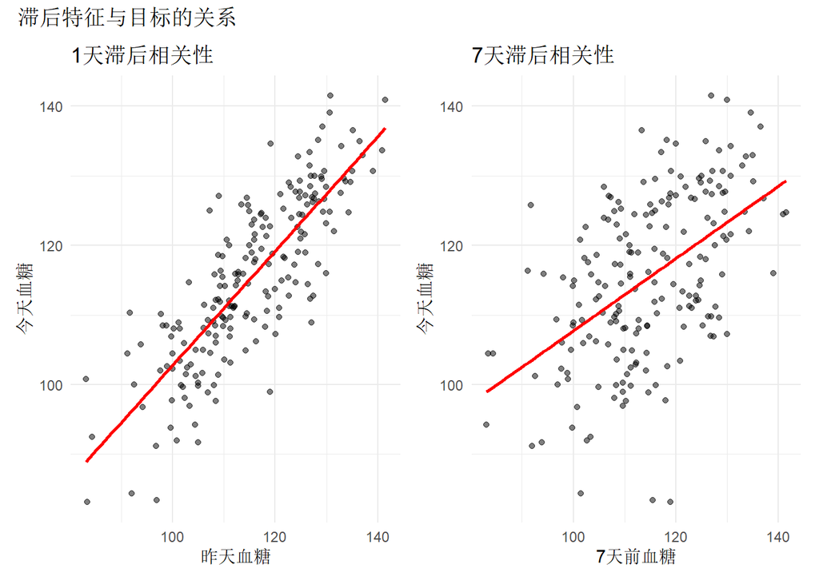

```r
# 滞后特征示例
# 添加多个滞后特征
ts_data$glucose_lag1 <- dplyr::lag(ts_data$glucose, 1)
ts_data$glucose_lag7 <- dplyr::lag(ts_data$glucose, 7)

# 可视化滞后关系
p1 <- ggplot2::ggplot(ts_data, ggplot2::aes(x = glucose_lag1, y = glucose)) +
  ggplot2::geom_point(alpha = 0.5) +
  ggplot2::geom_smooth(method = "lm", se = FALSE, color = "red") +
  ggplot2::labs(title = "1天滞后相关性", x = "昨天血糖", y = "今天血糖") +
  ggplot2::theme_minimal()

p2 <- ggplot2::ggplot(ts_data, ggplot2::aes(x = glucose_lag7, y = glucose)) +
  ggplot2::geom_point(alpha = 0.5) +
  ggplot2::geom_smooth(method = "lm", se = FALSE, color = "red") +
  ggplot2::labs(title = "7天滞后相关性", x = "7天前血糖", y = "今天血糖") +
  ggplot2::theme_minimal()

p1 + p2 + patchwork::plot_annotation(title = "滞后特征与目标的关系")
```

### 滚动统计特征

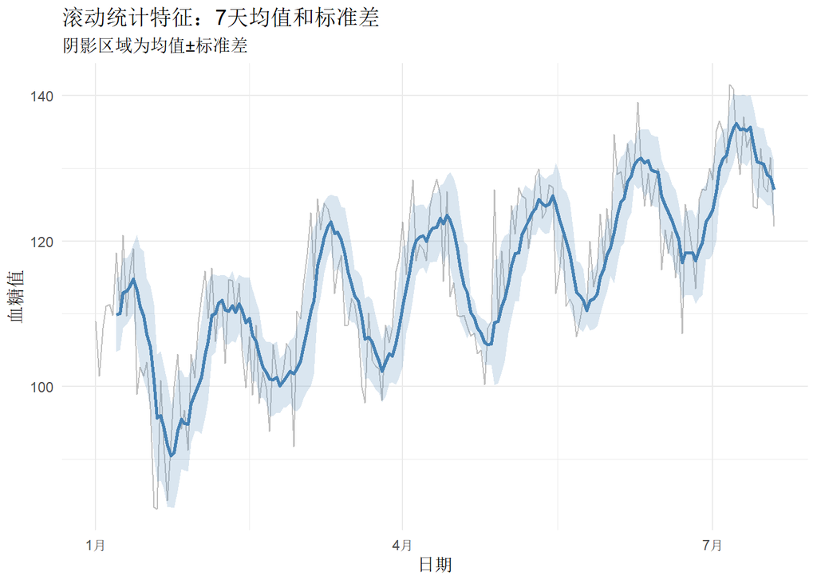

```r
# 滚动统计特征
# 计算滚动均值和滚动标准差
ts_data$rolling_mean_7 <- zoo::rollmean(ts_data$glucose, k = 7, fill = NA, align = "right")
ts_data$rolling_sd_7 <- zoo::rollapply(ts_data$glucose, width = 7, FUN = sd, fill = NA, align = "right")

# 可视化滚动统计
ggplot2::ggplot(ts_data, ggplot2::aes(x = date)) +
  ggplot2::geom_line(ggplot2::aes(y = glucose), color = "gray50", alpha = 0.5) +
  ggplot2::geom_line(ggplot2::aes(y = rolling_mean_7), color = "steelblue", linewidth = 1) +
  ggplot2::geom_ribbon(ggplot2::aes(ymin = rolling_mean_7 - rolling_sd_7,
                                     ymax = rolling_mean_7 + rolling_sd_7),
                       alpha = 0.2, fill = "steelblue") +
  ggplot2::labs(
    title = "滚动统计特征：7天均值和标准差",
    subtitle = "阴影区域为均值±标准差",
    x = "日期", y = "血糖值"
  ) +
  ggplot2::theme_minimal()
```

### 季节特征

[figure not shown]

```r
# 提取季节特征
ts_data$day_of_week <- weekdays(ts_data$date)
ts_data$day_of_month <- as.numeric(format(ts_data$date, "%d"))
ts_data$month <- as.numeric(format(ts_data$date, "%m"))
ts_data$is_weekend <- ts_data$day_of_week %in% c("Saturday", "Sunday")

# 可视化周内模式
weekly_pattern <- ts_data %>%
  dplyr::group_by(day_of_week) %>%
  dplyr::summarise(
    mean_glucose = mean(glucose, na.rm = TRUE),
    sd_glucose = sd(glucose, na.rm = TRUE)
  )

# 设置星期顺序
weekly_pattern$day_of_week <- factor(weekly_pattern$day_of_week,
                                      levels = c("Monday", "Tuesday", "Wednesday",
                                                "Thursday", "Friday", "Saturday", "Sunday"))

ggplot2::ggplot(weekly_pattern, ggplot2::aes(x = day_of_week, y = mean_glucose)) +
  ggplot2::geom_bar(stat = "identity", fill = "steelblue") +
  ggplot2::geom_errorbar(ggplot2::aes(ymin = mean_glucose - sd_glucose,
                                       ymax = mean_glucose + sd_glucose),
                         width = 0.2) +
  ggplot2::labs(
    title = "周内血糖模式",
    x = "星期", y = "平均血糖"
  ) +
  ggplot2::theme_minimal() +
  ggplot2::theme(axis.text.x = ggplot2::element_text(angle = 45, hjust = 1))
```

## 13.3 时间序列交叉验证

### 时间序列分割

**重要原则**：不能用未来数据预测过去，必须保持时间顺序。

```r
# 时间序列交叉验证示例
library(forecast)

# 创建时间序列对象
ts_glucose <- ts(ts_data$glucose, frequency = 30)  # 假设月周期

# 使用forecast包的时间序列CV
# 创建训练集和测试集
train_size <- floor(n_days * 0.8)
train_data <- ts_data$glucose[1:train_size]
test_data <- ts_data$glucose[(train_size + 1):n_days]

# 滚动预测
h <- 7  # 预测步长
n_windows <- 5  # 滚动窗口数

predictions <- data.frame()

for (i in 1:n_windows) {
  # 训练集结束点
  train_end <- train_size + (i - 1) * h

  if (train_end + h > n_days) break

  # 训练模型
  train_subset <- ts_data$glucose[1:train_end]
  fit <- forecast::auto.arima(train_subset)

  # 预测
  fc <- forecast::forecast(fit, h = h)

  # 存储结果
  predictions <- rbind(predictions, data.frame(
    window = i,
    date = ts_data$date[(train_end + 1):(train_end + h)],
    actual = ts_data$glucose[(train_end + 1):(train_end + h)],
    predicted = as.numeric(fc$mean)
  ))
}

# 计算预测误差
predictions$error <- predictions$actual - predictions$predicted
rmse <- sqrt(mean(predictions$error^2))
print(paste("RMSE:", round(rmse, 2)))
```

```
## [1] "RMSE: 8.4"
```

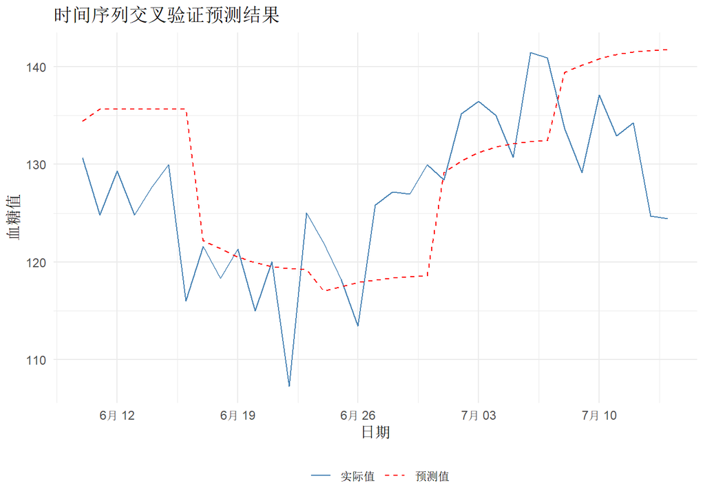

```r
# 可视化预测结果
ggplot2::ggplot(predictions, ggplot2::aes(x = date)) +
  ggplot2::geom_line(ggplot2::aes(y = actual, color = "实际值")) +
  ggplot2::geom_line(ggplot2::aes(y = predicted, color = "预测值"), linetype = "dashed") +
  ggplot2::scale_color_manual(values = c("实际值" = "steelblue", "预测值" = "red")) +
  ggplot2::labs(
    title = "时间序列交叉验证预测结果",
    x = "日期", y = "血糖值", color = ""
  ) +
  ggplot2::theme_minimal() +
  ggplot2::theme(legend.position = "bottom")
```

## 13.4 基于树的时序模型

### 随机森林应用于时序

```r
# 使用随机森林进行时间序列预测
set.seed(42)

# 准备特征数据
ts_features <- lagged_data[, -c(1, ncol(lagged_data))]  # 移除日期和目标
ts_target <- lagged_data$target

# 划分训练集和测试集
train_idx <- 1:floor(nrow(lagged_data) * 0.8)
train_x <- ts_features[train_idx, ]
train_y <- ts_target[train_idx]
test_x <- ts_features[-train_idx, ]
test_y <- ts_target[-train_idx]

# 训练随机森林
rf_ts <- randomForest::randomForest(
  x = as.matrix(train_x),
  y = train_y,
  ntree = 100,
  importance = TRUE
)

# 预测
rf_predictions <- predict(rf_ts, as.matrix(test_x))

# 评估
rf_rmse <- sqrt(mean((test_y - rf_predictions)^2))
print(paste("随机森林RMSE:", round(rf_rmse, 2)))
```

```
## [1] "随机森林RMSE: 6.43"
```

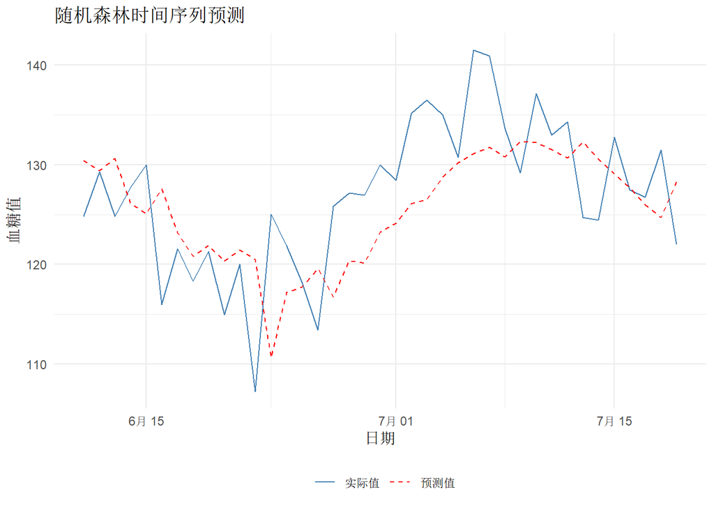

```r
# 可视化
results_df <- data.frame(
  date = lagged_data$date[-train_idx],
  actual = test_y,
  predicted = rf_predictions
)

ggplot2::ggplot(results_df, ggplot2::aes(x = date)) +
  ggplot2::geom_line(ggplot2::aes(y = actual, color = "实际值")) +
  ggplot2::geom_line(ggplot2::aes(y = predicted, color = "预测值"), linetype = "dashed") +
  ggplot2::scale_color_manual(values = c("实际值" = "steelblue", "预测值" = "red")) +
  ggplot2::labs(
    title = "随机森林时间序列预测",
    x = "日期", y = "血糖值", color = ""
  ) +
  ggplot2::theme_minimal() +
  ggplot2::theme(legend.position = "bottom")
```

## 13.5 Prophet模型

### Prophet原理

**Prophet** 是Facebook开发的时间序列预测模型，适合具有趋势和季节性的数据：

**模型组成**：
$$y(t) = g(t)
+ s(t) + h(t) + \epsilon_t$$

- $g(t)$：趋势项
- $s(t)$：季节项
- $h(t)$：节假日效应
- $\epsilon_t$：误差项

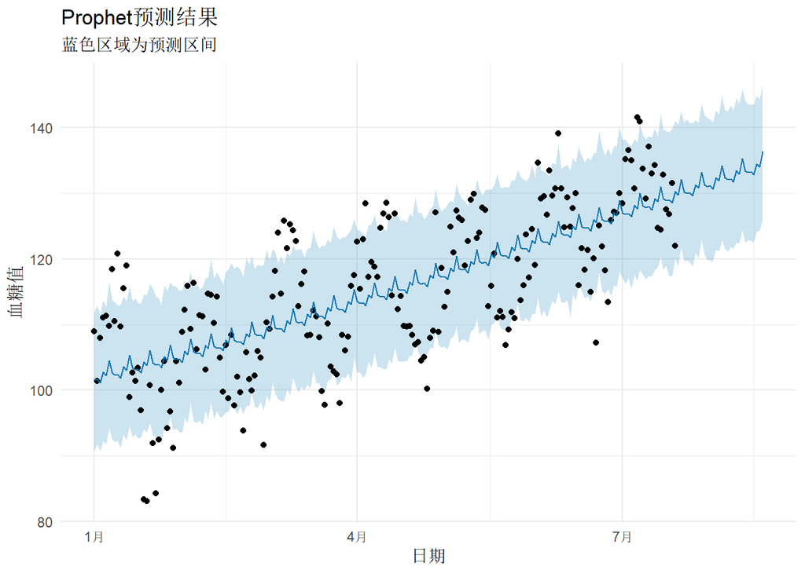

```r
# Prophet模型示例
library(prophet)

# 准备数据（Prophet需要ds和y两列）
prophet_data <- data.frame(
  ds = ts_data$date,
  y = ts_data$glucose
)

# 训练Prophet模型
prophet_model <- prophet::prophet(
  prophet_data,
  yearly.seasonality = FALSE,
  weekly.seasonality = TRUE,
  daily.seasonality = FALSE
)

# 创建未来数据框
future <- prophet::make_future_dataframe(prophet_model, periods = 30)

# 预测
prophet_forecast <- predict(prophet_model, future)

# 可视化
plot(prophet_model, prophet_forecast) +
  ggplot2::labs(
    title = "Prophet预测结果",
    subtitle = "蓝色区域为预测区间",
    x = "日期", y = "血糖值"
  ) +
  ggplot2::theme_minimal()
```

### Prophet组件分解

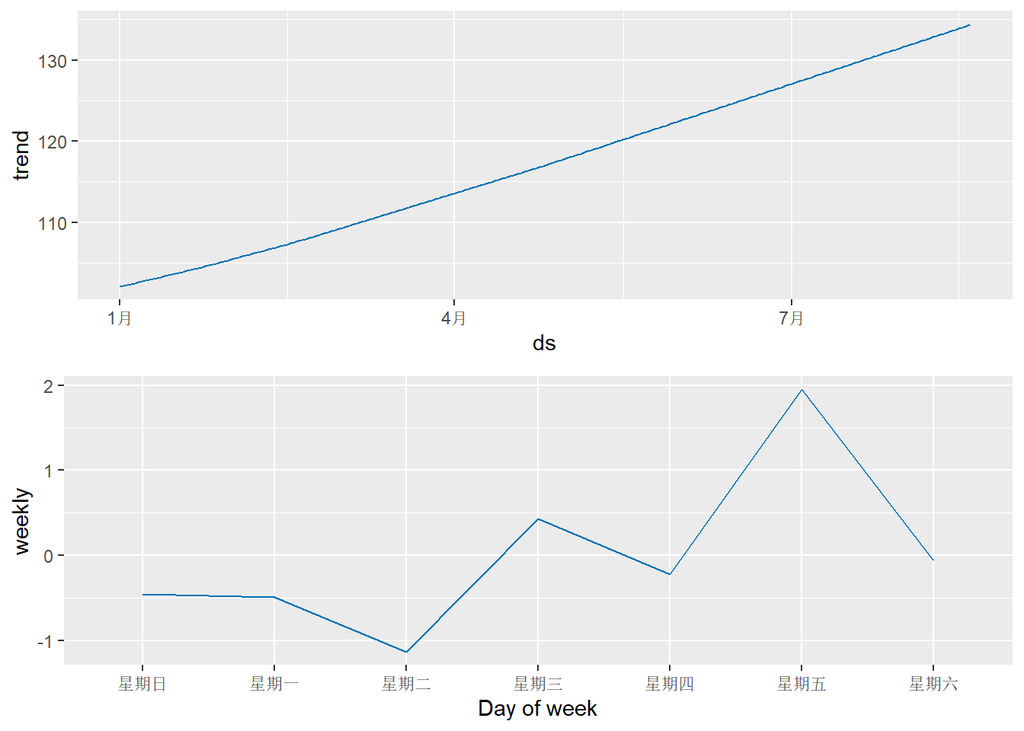

```r
# 查看Prophet的组件分解
prophet::prophet_plot_components(prophet_model, prophet_forecast)
```

### 意义与使用场景

**核心意义**：Prophet自动处理趋势和季节性，适合医学监测数据的预测。

**举例**：患者生命体征监测预测

**为什么这种数据适合用Prophet？**

生命体征数据通常有日周期（如血压早晚不同）、周周期（工作日vs周末）等季节性模式，Prophet可以自动捕捉这些模式。

**研究目的是什么？**

1. 异常预警：预测正常范围，检测异常值
2. 资源规划：预测医院就诊量
3. 效果评估：评估干预措施的长期效果

**可能得到什么样的结果？**

Prophet可能预测未来一周的血糖趋势，帮助医生调整治疗方案。

**需要注意什么？**

Prophet假设趋势和季节性是可加的，对于乘性关系可能需要变换。

## 13.6 时序聚类与异常检测

### 时间序列聚类

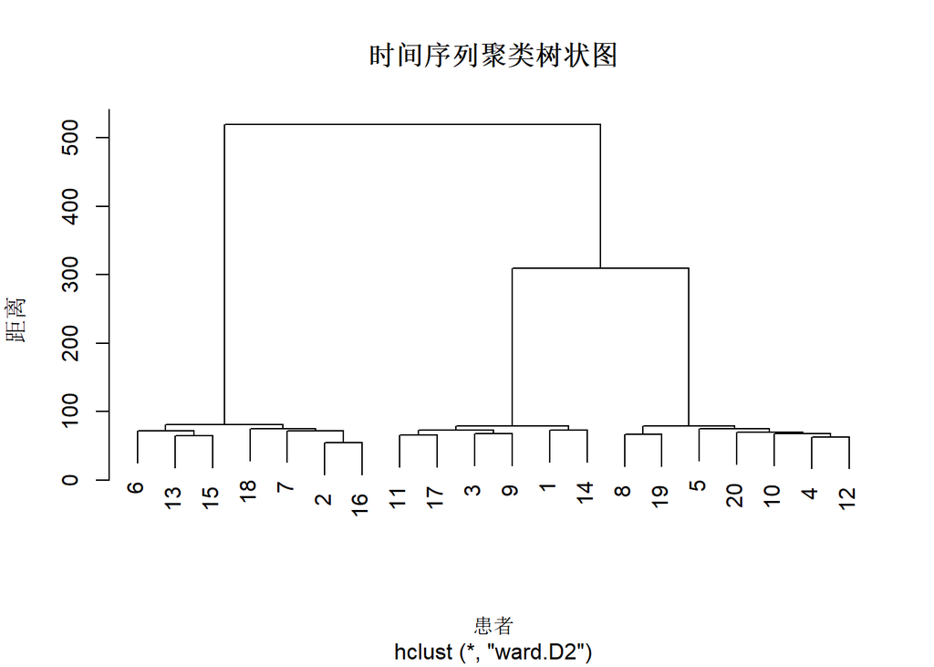

```r
# 时间序列聚类示例
set.seed(42)

# 创建多个患者的时间序列
n_patients <- 20
n_days <- 100

# 生成不同模式的时间序列
ts_list <- list()
for (i in 1:n_patients) {
  pattern_type <- sample(1:3, 1)

  if (pattern_type == 1) {
    # 上升趋势
    ts_list[[i]] <- seq(80, 120, length.out = n_days) + rnorm(n_days, 0, 5)
  } else if (pattern_type == 2) {
    # 下降趋势
    ts_list[[i]] <- seq(120, 80, length.out = n_days) + rnorm(n_days, 0, 5)
  } else {
    # 稳定趋势
    ts_list[[i]] <- rep(100, n_days) + rnorm(n_days, 0, 5)
  }
}

# 转换为矩阵
ts_matrix <- do.call(rbind, ts_list)

# 计算距离矩阵（动态时间规整）
# 简化：使用欧氏距离
dist_matrix <- dist(ts_matrix)

# 层次聚类
hc_result <- hclust(dist_matrix, method = "ward.D2")

# 可视化
plot(hc_result, main = "时间序列聚类树状图", xlab = "患者", ylab = "距离")
```

### 时间序列异常检测

```r
# 时间序列异常检测
# 使用预测残差检测异常

# 计算预测残差
residuals <- test_y - rf_predictions

# 定义异常阈值（3倍标准差）
threshold <- 3 * sd(residuals)

# 识别异常点
anomalies <- which(abs(residuals) > threshold)

print(paste("检测到", length(anomalies), "个异常点"))
```

```
## [1] "检测到 0 个异常点"
```

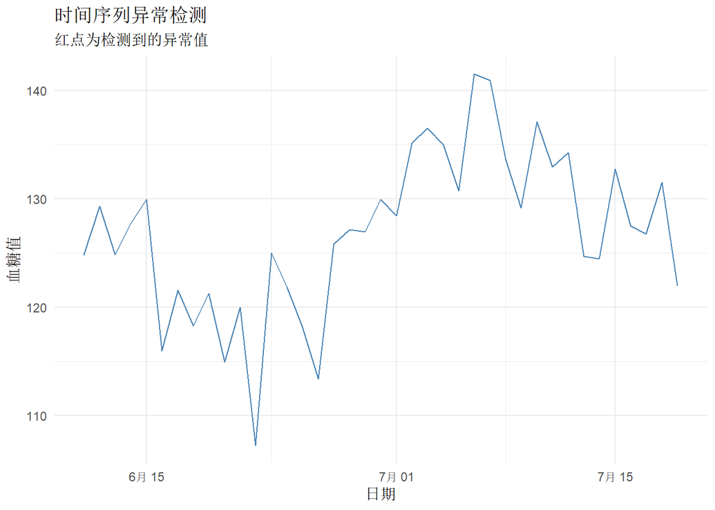

```r
# 可视化异常
results_df$is_anomaly <- abs(residuals) > threshold

ggplot2::ggplot(results_df, ggplot2::aes(x = date)) +
  ggplot2::geom_line(ggplot2::aes(y = actual), color = "steelblue") +
  ggplot2::geom_point(data = dplyr::filter(results_df, is_anomaly),
                      ggplot2::aes(y = actual), color = "red", size = 3) +
  ggplot2::labs(
    title = "时间序列异常检测",
    subtitle = "红点为检测到的异常值",
    x = "日期", y = "血糖值"
  ) +
  ggplot2::theme_minimal()
```

### 意义与使用场景

**核心意义**：时间序列聚类发现相似模式，异常检测识别异常事件。

**举例**：患者病情轨迹分析

**为什么这种数据适合用时序聚类？**

不同患者的病情发展轨迹可能属于不同类型，如”快速恢复型”、“缓慢恢复型”、“恶化型”。时序聚类可以发现这些模式。

**研究目的是什么？**

1. 模式发现：识别不同的病情发展模式
2. 预后预测：根据轨迹类型预测预后
3. 个体化治疗：针对不同轨迹类型制定方案

**可能得到什么样的结果？**

聚类可能发现3种血糖控制模式，每种模式需要不同的干预策略。

**需要注意什么？**

时间序列聚类对距离度量敏感，需要选择合适的距离方法（如DTW）。

# 第十四章 文本挖掘基础

## 14.1 文本预处理

### 文本挖掘概述

**文本挖掘（Text Mining）** 从非结构化文本中提取有价值的信息：

| 步骤 | 说明 |
| --- | --- |
| 文本收集 | 获取原始文本数据 |
| 文本预处理 | 清洗和标准化文本 |
| 特征提取 | 将文本转换为数值特征 |
| 模型构建 | 应用机器学习方法 |

### 分词

**分词（Tokenization）** 将文本切分为词语或标记：

```r
# 中文分词示例
# 使用简单的字符串分割方法演示分词概念
# 实际应用中可使用jiebaR等专门包

# 创建模拟的医疗文本数据
medical_texts <- c(
  "患者主诉头痛三天，伴有恶心呕吐症状",
  "既往有高血压病史五年，规律服药控制",
  "体格检查显示血压偏高，心率正常",
  "建议进行头部CT检查排除颅内病变"
)

# 简单分词：按标点和空格分割
simple_tokenize <- function(text) {
  # 使用正则表达式分割
  tokens <- unlist(strsplit(text, "[，。、；：！？\\s]+"))
  tokens <- tokens[nchar(tokens) > 0]
  paste(tokens, collapse = " | ")
}

# 进行分词
tokenized_texts <- sapply(medical_texts, simple_tokenize)

# 查看分词结果
print("分词结果：")
```

```
## [1] "分词结果："
```

```r
for (i in seq_along(medical_texts)) {
  cat("原文:", medical_texts[i], "\n")
  cat("分词:", tokenized_texts[i], "\n\n")
}
```

```
## 原文: 患者主诉头痛三天，伴有恶心呕吐症状
## 分词: 患者主诉头痛三天 | 伴有恶心呕吐症状
##
## 原文: 既往有高血压病史五年，规律服药控制
## 分词: 既往有高血压病史五年 | 规律服药控制
##
## 原文: 体格检查显示血压偏高，心率正常
## 分词: 体格检查显示血压偏高 | 心率正常
##
## 原文: 建议进行头部CT检查排除颅内病变
## 分词: 建议进行头部CT检查排除颅内病变
```

### 停用词处理

**停用词（Stop Words）** 是高频但信息量小的词，如”的”、“是”等。

```r
# 停用词处理
# 定义停用词列表
stop_words <- c("的", "是", "有", "在", "和", "了", "进行", "显示", "伴有")

# 移除停用词（简单示例）
remove_stopwords <- function(text, stop_words) {
  tokens <- unlist(strsplit(text, "[，。、；：！？\\s]+"))
  tokens <- tokens[!tokens %in% stop_words]
  tokens <- tokens[nchar(tokens) > 0]
  paste(tokens, collapse = " | ")
}

# 应用停用词移除
cleaned_texts <- sapply(medical_texts, function(x) {
  remove_stopwords(x, stop_words)
})

print("移除停用词后：")
```

```
## [1] "移除停用词后："
```

```r
for (i in seq_along(cleaned_texts)) {
  cat(cleaned_texts[i], "\n")
}
```

```
## 患者主诉头痛三天 | 伴有恶心呕吐症状
## 既往有高血压病史五年 | 规律服药控制
## 体格检查显示血压偏高 | 心率正常
## 建议进行头部CT检查排除颅内病变
```

### 词干提取与词形还原

**词干提取（Stemming）**：将词还原为词干 **词形还原（Lemmatization）**：将词还原为词典形式

```r
# 英文文本处理示例
library(SnowballC)

# 英文医疗文本
english_texts <- c(
  "The patient was diagnosed with diabetes",
  "Patients are receiving treatments for various diseases",
  "The medication effectively reduced the symptoms"
)

# 创建语料库
corpus <- tm::Corpus(tm::VectorSource(english_texts))

# 文本预处理：转小写、移除标点、移除停用词
corpus <- tm::tm_map(corpus, tm::content_transformer(tolower))
corpus <- tm::tm_map(corpus, tm::removePunctuation)
corpus <- tm::tm_map(corpus, tm::removeWords, tm::stopwords("en"))

# 词干提取
corpus <- tm::tm_map(corpus, tm::stemDocument)

# 查看处理结果
print("预处理后的文本：")
```

```
## [1] "预处理后的文本："
```

```r
for (i in 1:length(corpus)) {
  cat(corpus[[i]]$content, "\n")
}
```

```
## patient diagnos diabet
## patient receiv treatment various diseas
## medic effect reduc symptom
```

### 意义与使用场景

**核心意义**：文本预处理是文本挖掘的基础，直接影响后续分析质量。

**举例**：电子病历文本处理

**为什么这种数据适合用文本预处理？**

电子病历包含大量非结构化文本，如主诉、病程记录等。预处理可以将这些文本转换为可分析的结构化数据。

**研究目的是什么？**

1. 信息提取：从病历中提取关键信息
2. 文本分类：自动分类病历类型
3. 知识发现：发现疾病与症状的关联

**可能得到什么样的结果？**

预处理后可以从”患者主诉头痛三天”中提取”头痛”作为症状，“三天”作为持续时间。

**需要注意什么？**

中文分词质量对后续分析影响很大，需要选择合适的分词工具和自定义词典。

## 14.2 词袋模型与TF-IDF

### 词袋模型（BoW）

**词袋模型（Bag of Words）** 将文本表示为词频向量，忽略词序：

```r
# 词袋模型示例
# 使用tm包创建文档-词矩阵

# 创建模拟的医疗文本数据集
documents <- c(
  "高血压 糖尿病 冠心病",
  "高血压 冠心病 治疗",
  "糖尿病 肾病 治疗",
  "冠心病 糖尿病 高血压 治疗"
)

# 创建语料库
corpus <- tm::Corpus(tm::VectorSource(documents))

# 创建文档-词矩阵
dtm <- tm::DocumentTermMatrix(corpus)

# 查看矩阵
print("文档-词矩阵：")
```

```
## [1] "文档-词矩阵："
```

```r
tm::inspect(dtm)
```

```
## <<DocumentTermMatrix (documents: 4, terms: 5)>>
## Non-/sparse entries: 13/7
## Sparsity           : 35%
## Maximal term length: 3
## Weighting          : term frequency (tf)
## Sample             :
##     Terms
## Docs 高血压 冠心病 肾病 糖尿病 治疗
##    1      1      1    0      1    0
##    2      1      1    0      0    1
##    3      0      0    1      1    1
##    4      1      1    0      1    1
```

```r
# 转换为普通矩阵查看
dtm_matrix <- as.matrix(dtm)
print(dtm_matrix)
```

```
##     Terms
## Docs 冠心病 糖尿病 高血压 治疗 肾病
##    1      1      1      1    0    0
##    2      1      0      1    1    0
##    3      0      1      0    1    1
##    4      1      1      1    1    0
```

### TF-IDF

**TF-IDF（Term Frequency-Inverse Document Frequency）** 衡量词的重要性：

$$\text{TF-IDF}(t, d) = \text{TF}(t, d)
\times \text{IDF}(t)$$

$$\text{IDF}(t) =
\log\frac{N}{df(t)}$$

其中： - $\text{TF}(t, d)$：词t在文档d中的频率 - $N$：文档总数 - $df(t)$：包含词t的文档数

```r
# TF-IDF计算
# 创建带TF-IDF权重的文档-词矩阵
dtm_tfidf <- tm::weightTfIdf(dtm)

# 查看TF-IDF矩阵
tfidf_matrix <- as.matrix(dtm_tfidf)
print("TF-IDF矩阵：")
```

```
## [1] "TF-IDF矩阵："
```

```r
print(round(tfidf_matrix, 3))
```

```
##     Terms
## Docs 冠心病 糖尿病 高血压  治疗  肾病
##    1  0.138  0.138  0.138 0.000 0.000
##    2  0.138  0.000  0.138 0.138 0.000
##    3  0.000  0.138  0.000 0.138 0.667
##    4  0.104  0.104  0.104 0.104 0.000
```

```r
# 找出每个文档中最重要的词
for (i in 1:nrow(tfidf_matrix)) {
  top_words <- names(sort(tfidf_matrix[i, ], decreasing = TRUE))[1:2]
  print(paste("文档", i, "最重要的词:", paste(top_words, collapse = ", ")))
}
```

```
## [1] "文档 1 最重要的词: 冠心病, 糖尿病"
## [1] "文档 2 最重要的词: 冠心病, 高血压"
## [1] "文档 3 最重要的词: 肾病, 糖尿病"
## [1] "文档 4 最重要的词: 冠心病, 糖尿病"
```

### 意义与使用场景

**核心意义**：TF-IDF能够识别文档中的关键词，是文本分析的基础方法。

**举例**：医学文献关键词提取

**为什么这种数据适合用TF-IDF？**

医学文献中，专业术语（如疾病名称、药物名称）在某篇文献中频繁出现，但在所有文献中出现较少，TF-IDF可以识别这些关键词。

**研究目的是什么？**

1. 关键词提取：自动提取文献关键词
2. 文献检索：提高检索准确性
3. 文献分类：根据关键词分类文献

**可能得到什么样的结果？**

TF-IDF可能识别出”糖尿病”、“胰岛素抵抗”等作为某篇文献的关键词。

**需要注意什么？**

TF-IDF忽略词序和语义，对于需要理解上下文的任务可能不够。

## 14.3 N-gram模型

### N-gram原理

**N-gram** 是连续的N个词的序列，可以捕捉局部词序信息：

| N-gram类型 | 示例 |
| --- | --- |
| Unigram (1-gram) | “高血压”, “糖尿病” |
| Bigram (2-gram) | “高血压 患者”, “糖尿病 治疗” |
| Trigram (3-gram) | “高血压 患者 治疗” |

```r
# N-gram示例
library(tidytext)

# 创建医疗文本数据框
text_df <- data.frame(
  doc_id = 1:4,
  text = c(
    "高血压患者需要长期治疗",
    "糖尿病患者应控制饮食",
    "高血压和糖尿病都是慢性病",
    "慢性病需要长期管理和治疗"
  )
)

# 分词
tokens <- tidytext::unnest_tokens(text_df, word, text)

# 查看unigram结果
print("Unigram结果：")
```

```
## [1] "Unigram结果："
```

```r
head(tokens, 10)
```

```
##    doc_id   word
## 1       1 高血压
## 2       1   患者
## 3       1   需要
## 4       1   长期
## 5       1   治疗
## 6       2 糖尿病
## 7       2   患者
## 8       2     应
## 9       2   控制
## 10      2   饮食
```

```r
# 创建bigram
bigrams <- text_df %>%
  tidytext::unnest_tokens(bigram, text, token = "ngrams", n = 2)

# 查看bigram结果
print("Bigram结果：")
```

```
## [1] "Bigram结果："
```

```r
head(bigrams, 10)
```

```
##    doc_id      bigram
## 1       1 高血压 患者
## 2       1   患者 需要
## 3       1   需要 长期
## 4       1   长期 治疗
## 5       2 糖尿病 患者
## 6       2     患者 应
## 7       2     应 控制
## 8       2   控制 饮食
## 9       3   高血压 和
## 10      3   和 糖尿病
```

```r
# 统计bigram频率
bigram_counts <- bigrams %>%
  dplyr::count(bigram, sort = TRUE)

print("最常见的bigram：")
```

```
## [1] "最常见的bigram："
```

```r
head(bigram_counts, 10)
```

```
##         bigram n
## 1    需要 长期 2
## 2      和 治疗 1
## 3    和 糖尿病 1
## 4      应 控制 1
## 5      患者 应 1
## 6    患者 需要 1
## 7  慢性病 需要 1
## 8    控制 饮食 1
## 9      管理 和 1
## 10 糖尿病 患者 1
```

## 14.4 主题模型：LDA

### LDA原理

**潜在狄利克雷分配（LDA）** 是一种生成式概率模型，用于发现文档集合中的潜在主题：

**核心假设**： 1. 每个文档是多个主题的混合 2. 每个主题是词语的概率分布

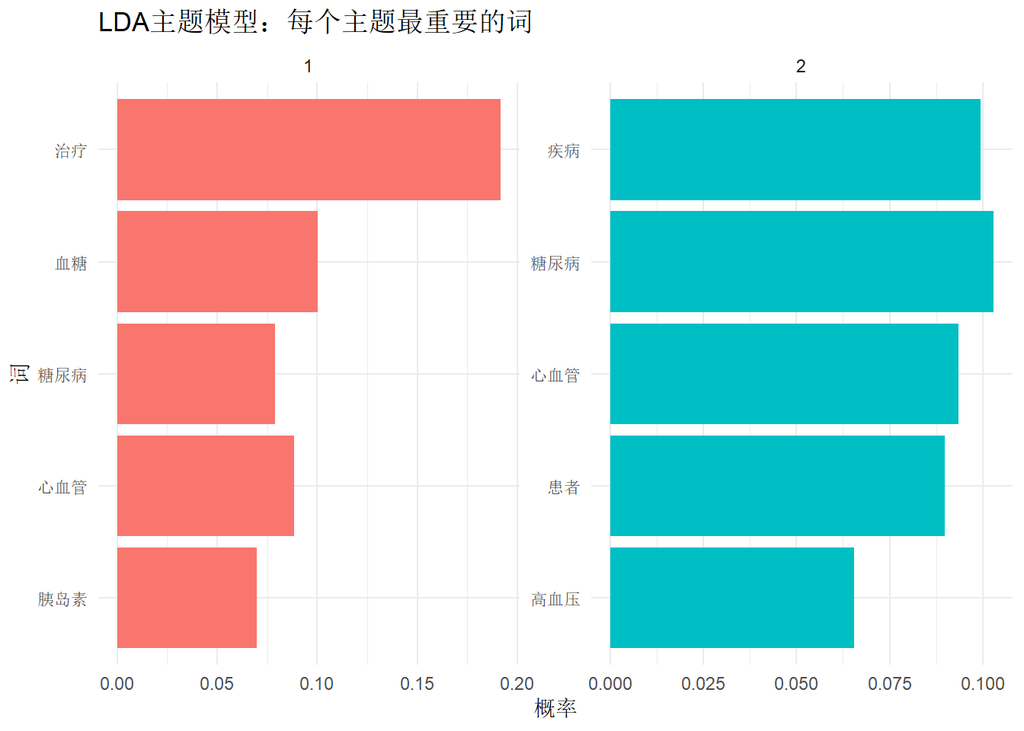

```r
# LDA主题模型示例
library(topicmodels)

# 创建模拟的医疗文档集合
medical_docs <- c(
  "高血压 血压 心血管 治疗 药物 患者",
  "糖尿病 血糖 胰岛素 治疗 患者 饮食",
  "高血压 心血管 疾病 风险 预防 治疗",
  "糖尿病 并发症 肾病 视网膜 病变",
  "心血管 冠心病 心脏 血管 疾病",
  "血糖 胰岛素 糖尿病 控制 治疗"
)

# 创建语料库和文档-词矩阵
corpus <- tm::Corpus(tm::VectorSource(medical_docs))
dtm <- tm::DocumentTermMatrix(corpus)

# 训练LDA模型
lda_model <- topicmodels::LDA(dtm, k = 2, control = list(seed = 42))

# 查看主题-词分布
topics <- tidytext::tidy(lda_model, matrix = "beta")

# 找出每个主题最重要的词
top_terms <- topics %>%
  dplyr::group_by(topic) %>%
  dplyr::slice_max(beta, n = 5) %>%
  dplyr::ungroup() %>%
  dplyr::arrange(topic, -beta)

# 可视化
ggplot2::ggplot(top_terms, ggplot2::aes(x = reorder(term, beta), y = beta, fill = factor(topic))) +
  ggplot2::geom_bar(stat = "identity", show.legend = FALSE) +
  ggplot2::facet_wrap(~ topic, scales = "free") +
  ggplot2::coord_flip() +
  ggplot2::labs(
    title = "LDA主题模型：每个主题最重要的词",
    x = "词", y = "概率"
  ) +
  ggplot2::theme_minimal()
```

### 意义与使用场景

**核心意义**：LDA可以发现文档集合中的潜在主题，是文本分析的重要工具。

**举例**：医学文献主题发现

**为什么这种数据适合用LDA？**

医学文献数量庞大，人工分类困难。LDA可以自动发现文献中的主要研究主题，帮助研究者快速了解领域动态。

**研究目的是什么？**

1. 主题发现：识别文献中的主要研究主题
2. 文献分类：根据主题自动分类文献
3. 趋势分析：分析研究主题的时间变化

**可能得到什么样的结果？**

LDA可能发现”心血管疾病”、“糖尿病治疗”等主题，每个主题包含相关的关键词。

**需要注意什么？**

主题数量K需要预先指定，可以使用困惑度等方法选择最优K值。

## 14.5 文本分类

### 文本分类概述

**文本分类** 将文档分配到预定义的类别：

```r
# 文本分类示例
# 使用朴素贝叶斯分类器

set.seed(42)

# 创建模拟的医疗文本分类数据
text_class_data <- data.frame(
  text = c(
    "患者血压偏高，诊断为高血压",
    "血糖控制不佳，糖尿病诊断明确",
    "心脏彩超显示心功能下降",
    "胰岛素治疗糖尿病效果良好",
    "高血压药物治疗后血压稳定",
    "冠心病患者需要长期服药"
  ),
  category = factor(c("高血压", "糖尿病", "心血管", "糖尿病", "高血压", "心血管"))
)

# 创建语料库
corpus <- tm::Corpus(tm::VectorSource(text_class_data$text))

# 预处理
corpus <- tm::tm_map(corpus, tm::content_transformer(tolower))
corpus <- tm::tm_map(corpus, tm::removePunctuation)

# 创建文档-词矩阵
dtm <- tm::DocumentTermMatrix(corpus)

# 划分训练集和测试集
train_idx <- sample(1:nrow(text_class_data), size = 4)
test_idx <- setdiff(1:nrow(text_class_data), train_idx)

train_dtm <- dtm[train_idx, ]
test_dtm <- dtm[test_idx, ]

train_labels <- text_class_data$category[train_idx]
test_labels <- text_class_data$category[test_idx]

# 使用朴素贝叶斯分类器
# 训练模型
classifier <- e1071::naiveBayes(as.matrix(train_dtm), train_labels)

# 预测
predictions <- predict(classifier, as.matrix(test_dtm))

# 评估
print("预测结果：")
```

```
## [1] "预测结果："
```

```r
print(data.frame(
  实际 = test_labels,
  预测 = predictions
))
```

```
##     实际   预测
## 1 糖尿病 高血压
## 2 心血管 高血压
```

```r
# 计算准确率
accuracy <- mean(predictions == test_labels)
print(paste("准确率:", round(accuracy, 2)))
```

```
## [1] "准确率: 0"
```

## 14.6 词嵌入基础

### 词嵌入概念

**词嵌入（Word Embedding）** 将词映射到低维向量空间，捕捉语义关系：

| 方法 | 特点 |
| --- | --- |
| Word2Vec | 预测上下文或目标词 |
| GloVe | 基于全局共现矩阵 |
| FastText | 考虑子词信息 |

**核心思想**：语义相似的词在向量空间中距离较近。

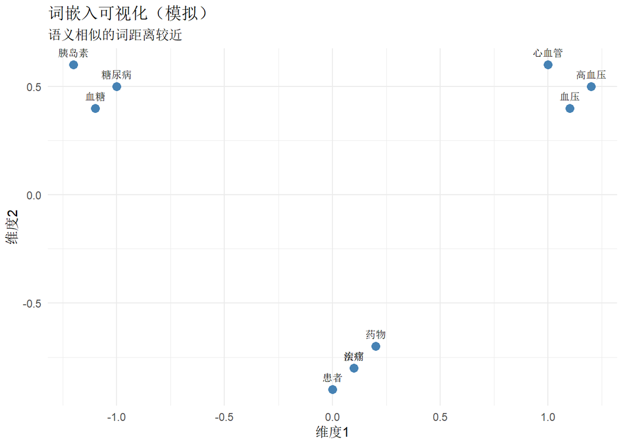

```r
# 词嵌入概念演示
# 注意：实际应用需要大量文本数据训练

# 模拟词嵌入向量
set.seed(42)

# 创建模拟的医疗词向量
words <- c("高血压", "血压", "心血管", "糖尿病", "血糖", "胰岛素",
           "治疗", "药物", "患者", "疾病")

# 模拟2维词向量（实际通常是100-300维）
word_vectors <- data.frame(
  word = words,
  dim1 = c(1.2, 1.1, 1.0, -1.0, -1.1, -1.2, 0.1, 0.2, 0.0, 0.1),
  dim2 = c(0.5, 0.4, 0.6, 0.5, 0.4, 0.6, -0.8, -0.7, -0.9, -0.8)
)

# 可视化词向量
ggplot2::ggplot(word_vectors, ggplot2::aes(x = dim1, y = dim2)) +
  ggplot2::geom_point(size = 3, color = "steelblue") +
  ggplot2::geom_text(ggplot2::aes(label = word), vjust = -1, size = 3) +
  ggplot2::labs(
    title = "词嵌入可视化（模拟）",
    subtitle = "语义相似的词距离较近",
    x = "维度1", y = "维度2"
  ) +
  ggplot2::theme_minimal()
```

### 意义与使用场景

**核心意义**：词嵌入捕捉词语的语义关系，是现代NLP的基础。

**举例**：医学文本语义分析

**为什么这种数据适合用词嵌入？**

医学文本中，“高血压”和”血压”语义相关，词嵌入可以捕捉这种关系，用于文本相似度计算、信息检索等。

**研究目的是什么？**

1. 语义搜索：根据语义相似度检索文档
2. 文本聚类：基于语义相似度聚类文档
3. 特征提取：用词向量作为下游任务的特征

**可能得到什么样的结果？**

词嵌入可能发现”糖尿病”与”胰岛素”距离较近，反映它们的语义关联。

**需要注意什么？**

词嵌入需要大量文本训练，对于医学领域建议使用领域语料训练或微调。

# 第十五章 推荐系统基础

## 15.1 推荐系统概述

### 什么是推荐系统？

**推荐系统（Recommender System）** 预测用户对物品的偏好，提供个性化推荐：

| 类型 | 说明 | 示例 |
| --- | --- | --- |
| 协同过滤 | 基于用户行为相似性 | Netflix电影推荐 |
| 基于内容 | 基于物品特征相似性 | 新闻推荐 |
| 混合方法 | 结合多种方法 | 亚马逊商品推荐 |

### 推荐系统在医学中的应用

| 应用场景 | 说明 |
| --- | --- |
| 治疗方案推荐 | 根据相似患者推荐治疗方案 |
| 药物推荐 | 根据病情推荐合适药物 |
| 健康内容推荐 | 推荐相关健康知识 |
| 医生推荐 | 推荐合适的医生 |

### 意义与使用场景

**核心意义**：推荐系统帮助用户从海量信息中发现感兴趣的内容。

**举例**：治疗方案推荐

**为什么这种数据适合用推荐系统？**

不同患者对同一治疗方案的反应可能不同。推荐系统可以根据相似患者的治疗历史，为新患者推荐可能有效的治疗方案。

**研究目的是什么？**

1. 个性化治疗：为患者推荐最适合的治疗方案
2. 辅助决策：为医生提供决策支持
3. 提高疗效：选择最可能有效的治疗

**可能得到什么样的结果？**

系统可能推荐”对于类似患者，方案A的有效率为80%“。

**需要注意什么？**

医疗推荐需要谨慎，推荐结果应作为参考而非决定。

## 15.2 协同过滤

### 基于用户的协同过滤

**原理**：找到与目标用户相似的用户，推荐这些用户喜欢的物品。

```r
# 协同过滤示例
library(recommenderlab)

# 创建模拟的用户-物品评分矩阵
# 假设是患者-治疗方案评分
set.seed(42)

# 创建评分矩阵
n_users <- 20
n_items <- 10

# 模拟评分数据（1-5分）
ratings <- matrix(sample(c(1:5, NA), n_users * n_items, replace = TRUE,
                          prob = c(0.1, 0.1, 0.2, 0.3, 0.2, 0.1)),
                  nrow = n_users, ncol = n_items)
colnames(ratings) <- paste0("治疗", 1:n_items)
rownames(ratings) <- paste0("患者", 1:n_users)

# 转换为realRatingMatrix
rating_matrix <- as(ratings, "realRatingMatrix")

# 查看数据摘要
print("评分矩阵摘要：")
```

```
## [1] "评分矩阵摘要："
```

```r
print(dim(rating_matrix))
```

```
## [1] 20 10
```

```r
print("评分分布：")
```

```
## [1] "评分分布："
```

```r
print(table(getRatings(rating_matrix)))
```

```
##
##  1  2  3  4  5
## 26 14 40 56 33
```

```r
# 训练基于用户的协同过滤模型
ubcf_model <- recommenderlab::Recommender(
  rating_matrix,
  method = "UBCF",
  param = list(method = "cosine", nn = 5)
)

# 为前3个患者推荐治疗
recommendations <- recommenderlab::predict(ubcf_model, rating_matrix[1:3], n = 3)

# 查看推荐结果
print("推荐结果：")
```

```
## [1] "推荐结果："
```

```r
rec_list <- as(recommendations, "list")
for (i in 1:3) {
  cat("患者", i, "的推荐治疗:", rec_list[[i]], "\n")
}
```

```
## 患者 1 的推荐治疗:
## 患者 2 的推荐治疗:
## 患者 3 的推荐治疗: 治疗4
```

### 基于物品的协同过滤

**原理**：找到与用户喜欢的物品相似的物品进行推荐。

```r
# 基于物品的协同过滤
ibcf_model <- recommenderlab::Recommender(
  rating_matrix,
  method = "IBCF",
  param = list(k = 5)
)

# 推荐
recommendations_ibcf <- recommenderlab::predict(ibcf_model, rating_matrix[1:3], n = 3)

# 查看推荐结果
print("基于物品的协同过滤推荐结果：")
```

```
## [1] "基于物品的协同过滤推荐结果："
```

```r
rec_list_ibcf <- as(recommendations_ibcf, "list")
for (i in 1:3) {
  cat("患者", i, "的推荐治疗:", rec_list_ibcf[[i]], "\n")
}
```

```
## 患者 1 的推荐治疗:
## 患者 2 的推荐治疗:
## 患者 3 的推荐治疗: 治疗4
```

## 15.3 矩阵分解

### SVD矩阵分解

**原理**：将用户-物品矩阵分解为用户矩阵和物品矩阵的乘积：

$$R \approx U \times V^T$$

```r
# 矩阵分解示例
# 使用SVD进行推荐

# 将评分矩阵转换为数值矩阵（NA用0填充）
ratings_filled <- ratings
ratings_filled[is.na(ratings_filled)] <- 0

# 执行SVD
svd_result <- svd(ratings_filled)

# 选择前k个奇异值
k <- 5
U_k <- svd_result$u[, 1:k]
V_k <- svd_result$v[, 1:k]
D_k <- diag(svd_result$d[1:k])

# 重构评分矩阵
ratings_predicted <- U_k %*% D_k %*% t(V_k)

# 查看预测评分
print("预测评分矩阵（前5行5列）：")
```

```
## [1] "预测评分矩阵（前5行5列）："
```

```r
print(round(ratings_predicted[1:5, 1:5], 2))
```

```
##      [,1] [,2] [,3] [,4] [,5]
## [1,] 1.32 1.47 4.95 2.34 4.33
## [2,] 0.88 2.63 4.60 2.59 5.23
## [3,] 2.69 1.46 3.86 2.28 4.22
## [4,] 2.29 1.98 1.39 1.73 2.56
## [5,] 3.63 2.77 4.06 3.21 0.97
```

## 15.4 基于内容的推荐

### 基本原理

**基于内容的推荐** 根据物品特征和用户偏好进行推荐：

```r
# 基于内容的推荐示例
# 假设治疗方案有特征描述

# 创建治疗方案特征
treatment_features <- data.frame(
  治疗 = paste0("治疗", 1:6),
  类型 = c("药物", "手术", "药物", "物理", "药物", "手术"),
  侵入性 = c(1, 5, 1, 2, 1, 4),
  成本 = c(2, 5, 3, 2, 4, 5),
  恢复时间 = c(1, 5, 2, 2, 3, 4)
)

print("治疗方案特征：")
```

```
## [1] "治疗方案特征："
```

```r
print(treatment_features)
```

```
##    治疗 类型 侵入性 成本 恢复时间
## 1 治疗1 药物      1    2        1
## 2 治疗2 手术      5    5        5
## 3 治疗3 药物      1    3        2
## 4 治疗4 物理      2    2        2
## 5 治疗5 药物      1    4        3
## 6 治疗6 手术      4    5        4
```

```r
# 用户偏好（假设用户偏好低侵入性、低成本）
user_preference <- c(侵入性 = -0.5, 成本 = -0.3, 恢复时间 = -0.2)

# 计算每个治疗的得分
scores <- as.matrix(treatment_features[, 3:5]) %*% user_preference
treatment_features$推荐得分 <- scores

# 排序推荐
treatment_features <- treatment_features[order(-treatment_features$推荐得分), ]

print("推荐排序：")
```

```
## [1] "推荐排序："
```

```r
print(treatment_features[, c("治疗", "类型", "推荐得分")])
```

```
##    治疗 类型 推荐得分
## 1 治疗1 药物     -1.3
## 3 治疗3 药物     -1.8
## 4 治疗4 物理     -2.0
## 5 治疗5 药物     -2.3
## 6 治疗6 手术     -4.3
## 2 治疗2 手术     -5.0
```

## 15.5 冷启动问题

### 冷启动类型

| 类型 | 说明 | 解决方案 |
| --- | --- | --- |
| 新用户 | 没有用户历史数据 | 基于人口统计学推荐 |
| 新物品 | 没有物品评分数据 | 基于内容推荐 |
| 系统冷启动 | 系统刚上线 | 使用热门推荐 |

```r
# 冷启动解决方案示例

# 新用户：基于人口统计学特征推荐
user_profiles <- data.frame(
  用户 = paste0("用户", 1:5),
  年龄段 = c("青年", "中年", "老年", "青年", "中年"),
  性别 = c("男", "女", "男", "女", "男"),
  偏好治疗 = c("治疗1", "治疗2", "治疗3", "治疗1", "治疗2")
)

# 对于新用户，根据人口统计学特征推荐
new_user <- data.frame(年龄段 = "青年", 性别 = "男")

# 找到相似用户
similar_users <- user_profiles %>%
  dplyr::filter(年龄段 == new_user$年龄段, 性别 == new_user$性别)

print("相似用户的偏好：")
```

```
## [1] "相似用户的偏好："
```

```r
print(similar_users)
```

```
##    用户 年龄段 性别 偏好治疗
## 1 用户1   青年   男    治疗1
```

## 15.6 评估指标

### 推荐系统评估指标

| 指标 | 公式 | 说明 |
| --- | --- | --- |
| RMSE | $\sqrt{\frac{1}{n}\sum(r - \hat{r})^2}$ | 预测误差 |
| 精确率@K | 相关推荐数/K | 前K个推荐的准确率 |
| 召回率@K | 相关推荐数/总相关数 | 找到相关物品的比例 |
| NDCG | 考虑排序位置的指标 | 排序质量 |

```r
# 评估指标计算示例
# 使用交叉验证评估推荐模型

# 创建评估方案
evaluation_scheme <- recommenderlab::evaluationScheme(
  rating_matrix,
  method = "split",
  train = 0.8,
  given = 3,
  goodRating = 4
)

# 训练多个模型
models <- list(
  UBCF = recommenderlab::Recommender(getData(evaluation_scheme, "train"), method = "UBCF"),
  IBCF = recommenderlab::Recommender(getData(evaluation_scheme, "train"), method = "IBCF")
)

# 评估
results <- recommenderlab::evaluate(evaluation_scheme, models, n = c(1, 3, 5))
```

[output not shown]

```r
# 查看结果
print("评估结果：")
```

```
## [1] "评估结果："
```

```r
print(results)
```

```
## List of evaluation results for 0 recommenders:
##
## named list()
```

```r
# 绘制ROC曲线（如果数据充足）
tryCatch({
  plot(results, annotate = TRUE, main = "推荐系统ROC曲线")
}, error = function(e) {
  print("ROC曲线绘制需要更多数据")
})
```

```
## [1] "ROC曲线绘制需要更多数据"
```

### 意义与使用场景

**核心意义**：评估指标帮助选择最优的推荐算法和参数。

**举例**：治疗方案推荐系统评估

**为什么需要评估指标？**

不同的推荐算法可能适合不同的场景，需要通过评估指标选择最适合的算法。

**研究目的是什么？**

1. 算法选择：比较不同算法的性能
2. 参数调优：找到最优参数
3. 系统优化：持续改进推荐质量

**可能得到什么样的结果？**

评估可能发现UBCF在精确率上优于IBCF，但IBCF计算效率更高。

**需要注意什么？**

离线评估指标可能与实际用户体验不一致，需要结合在线A/B测试。

# 总结

本教程涵盖了机器学习的核心内容：

| 章节 | 主题 | 核心方法 |
| --- | --- | --- |
| 第九章 | 无监督学习 | K-Means、DBSCAN、PCA、t-SNE |
| 第十章 | 关联规则 | Apriori、FP-Growth |
| 第十一章 | 特征选择 | 过滤法、包装法、嵌入法 |
| 第十二章 | 模型解释 | SHAP、LIME、PDP |
| 第十三章 | 时间序列 | 滑动窗口、Prophet |
| 第十四章 | 文本挖掘 | TF-IDF、LDA、词嵌入 |
| 第十五章 | 推荐系统 | 协同过滤、矩阵分解 |